# Online Companion to *Occupational Mobility Is Not One Thing: Evidence from the Canadian Labour Market*

Author

Richard Martin

## Overview

This companion is designed to ensure transparency and reproducibility for the paper *Occupational Mobility Is Not One Thing: Evidence from the Canadian Labour Market*. It provides technical detail on distance metrics, normalization, and specificity measures.

**Contents**

- **Skill distance**: O*NET-based occupational skill vectors, dimensionality reduction via PCA, and the resulting continuous distance matrix.
- **Hierarchical distance**: Taxonomy-based discrete distances derived from the NOC structure, resulting in labour market silos with internal TEER platforms.
- **Cost matrix normalization**: Percentile-based anchoring across distance metrics.
- **Occupation’s education specificity**: A size-adjusted measure of concentration in educational inflows into occupations.
- **Education’s occupation specificity**: A size-adjusted measure of concentration in occupational outcomes across fields of study and attainment levels.

## Skill Distance

We use 161 occupational characteristics (Skills, Abilities, Knowledge, Work Activities) from O*NET to measure the distance between occupations. Because occupational skill vectors are high-dimensional and highly correlated, Euclidean distances computed in the full feature space may suffer from distance concentration. We therefore project the data onto the 12 leading principal components, which achieve a 99% rank correlation of pairwise distances relative to the full 161-dimensional space. This reduces noise from low-variance directions while preserving the dominant geometry of the skill space.

### PCA Rank Preservation

The figure below shows the Spearman rank correlation between pairwise distances in the $k$-dimensional PCA space and the full 161-dimensional space, as a function of $k$. The dashed line marks the 0.99 threshold; 12 components suffice.

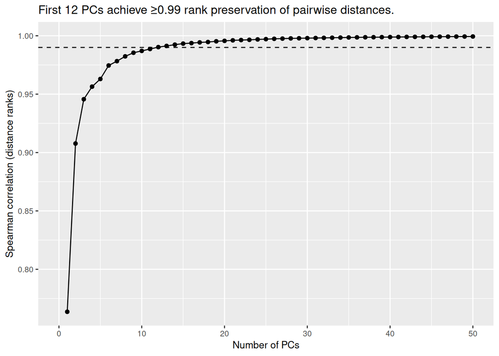

```r
ggplot(k_vs_spearman, aes(x = k, y = spearman)) +
  geom_hline(yintercept = .99, lty = 2) +
  geom_line() +
  geom_point() +
  scale_x_continuous(limits = c(0, 50)) +
  labs(
    title = "First 12 PCs achieve ≥0.99 rank preservation of pairwise distances.",
    y = "Spearman correlation (distance ranks)",
    x = "Number of PCs"
  ) +
  theme(text = element_text(size = 10))
```

### Raw Skill Distance Heatmap

Occupations are ordered by AGNES. Diagonal entries are self-distances (zero). Dark clusters along the diagonal indicate groups of occupations with similar skill profiles. Use left mouse button drag to zoom. Raw distances are normalized prior to use: Cost Matrix Normalization

```r
plotly::plot_ly(
  x = skills_xlab,
  y = skills_ylab,
  z = skills_mat_ord,
  type = "heatmap",
  hovertemplate = paste(
    "<b>Origin:</b> %{y}<br>",
    "<b>Destination:</b> %{x}<br>",
    "<b>Distance:</b> %{z:.3f}",
    "<extra></extra>"
  )
) |>
  plotly::layout(
    xaxis = list(type = "category", showticklabels = FALSE, ticks = ""),
    yaxis = list(type = "category", showticklabels = FALSE, ticks = "")
)
```

[interactive chart not shown]

## Hierarchical Distance

Hierarchical distances encode institutional and career barriers implied by the NOC taxonomy. Distance between any two occupations is defined as follows:

1. All five digits match: distance = 0
2. First four digits match: distance = 1
3. First three digits match: distance = 2
4. First digit matches: distance = 3 + |ΔTEER|
5. Otherwise: distance = 9

The Spearman correlation between skill and hierarchical distances is 0.289, indicating that institutional proximity and skill similarity are positively but only modestly related. The two metrics encode overlapping yet distinct occupational geometries.

### Distance Counts

```r
hier_count_plot <- table(hier) |>
  enframe() |>
  ggplot(aes(name, value)) +
  geom_col(alpha = .5) +
  scale_y_continuous(trans = "log10", labels = scales::comma) +
  theme_minimal() +
  labs(x = "Normalized Distance", y = "Counts")

plotly::ggplotly(hier_count_plot)
```

[interactive chart not shown]

### Raw Hierarchical Distance Heatmap

Occupations are ordered by AGNES. The block-diagonal structure reflects the ten NOC broad occupational categories (silos); yellow off-diagonal entries are cross-silo pairs assigned the sentinel distance of 9. Raw distances are normalized prior to use: Cost Matrix Normalization. Use left mouse button drag to zoom.

```r
hier_hc      <- hclust(as.dist(hier), method = "average")
hier_ord     <- hier_hc$order
hier_mat_ord <- hier[hier_ord, hier_ord]
hier_xlab    <- as.character(colnames(hier_mat_ord))
hier_ylab    <- as.character(rownames(hier_mat_ord))

plotly::plot_ly(
  x = hier_xlab,
  y = hier_ylab,
  z = hier_mat_ord,
  type = "heatmap",
  hovertemplate = paste(
    "<b>Origin:</b> %{y}<br>",
    "<b>Destination:</b> %{x}<br>",
    "<b>Distance:</b> %{z:.3f}",
    "<extra></extra>"
  )
) |>
  plotly::layout(
    xaxis = list(type = "category", showticklabels = FALSE, ticks = ""),
    yaxis = list(type = "category", showticklabels = FALSE, ticks = "")
  )
```

[interactive chart not shown]

## Cost Matrix Normalization

The normalization anchor is hierarchical distance 3 — the maximum within-silo horizontal distance, representing movement within a broad occupational group without crossing TEER levels. This anchor is theoretically motivated: any hierarchical distance above 3 involves either a TEER step or a cross-category transition, meaning distance 3 is the natural boundary between horizontal and vertical mobility within the silo structure. Hierarchical distances are divided by 3; skill distances are divided by 7.145, the value at the same unconditional percentile of the skill distance distribution.

```r
calibration |>
  gt() |>
  fmt_number(columns = c(h_anchor, p_uncond, s_anchor), decimals = 3) |>
  cols_label(
    h_anchor = "Hierarchical Anchor",
    p_uncond = "Unconditional Percentile",
    s_anchor = "Skill Anchor"
  ) |>
  tab_options(table.font.size = "90%", data_row.padding = px(4)) |>
  tab_header(title = md("**Calibration Anchors Across Distance Metrics**"))
```

**Calibration Anchors Across Distance Metrics**

| Hierarchical Anchor | Unconditional Percentile | Skill Anchor |
| --- | --- | --- |
| 2.000 | 0.016 | 5.684 |
| 3.000 | 0.040 | 7.145 |
| 4.000 | 0.081 | 8.590 |

The median non-maximal hierarchical transition lies at approximately the 4th percentile of the full hierarchical distribution; the skill anchor is defined at this same percentile to ensure comparable substitution intensity.

## Occupation’s Education Specificity

### Construction

**Step 1 — Overall Educational Distribution.** We compute the overall educational distribution across all NOCs. This represents the expected education mix for a worker drawn from the educated workforce without conditioning on occupation.

**Step 2 — Distribution Within Each NOC.** For each NOC we compute total workers $T$, occupation-specific education shares $p$, and compare to the baseline distribution $p_0$ using KL divergence.

**Step 3 — Remove Size Effect.** Finite samples mechanically inflate divergence for small occupations. We remove this artifact by residualizing $\log(\text{KL})$ on $\log(T)$:

```r
fit_kl <- lm(log(KL) ~ log(T), data = noc_edu_spec)

noc_edu_spec <- noc_edu_spec |>
  mutate(
    specificity = log(KL) - predict(fit_kl),
    TEER = str_sub(noc, 2, 2)
  )
```

The resulting specificity index measures how distinct an occupation’s education mix is relative to what is statistically expected given its size. KL divergence captures where probability mass is concentrated relative to the aggregate baseline, rather than how much mass lies in very small cells. Residualizing removes predictable finite-sample divergence, isolating economically meaningful concentration. The index is orthogonal to occupation size by construction, ensuring that specificity reflects structural concentration in educational pathways rather than equilibrium scale effects.

### Specificity vs. Occupation Size

High specificity indicates few educational pathways into the occupation. Residualized specificity is not correlated with log occupation size (Pearson = -0.03, Spearman = 0.03).

```r
p <- ggplotly(dest_plt)
p$x$data <- rev(p$x$data)
p
```

[interactive chart not shown]

### Occupation Specificity Rankings

```r
noc_edu_spec |>
  select(noc, specificity, contains("Based On")) |>
  arrange(desc(specificity)) |>
  my_dt()
```

| noc | specificity | Based on TEER | Based on Occupation Education Specificity |
| --- | --- | --- | --- |
| 31111: Optometrists | 1.520386168984727 | Binary | Binary |
| 31110: Dentists | 1.48422464458365 | Binary | Binary |
| 31103: Veterinarians | 1.481257965506515 | Binary | Binary |
| 31112: Audiologists and speech-language pathologists | 1.451702799389202 | Binary | Binary |
| 31201: Chiropractors | 1.391880980529879 | Binary | Binary |
| 31120: Pharmacists | 1.377772124248384 | Binary | Binary |
| 31102: General practitioners and family physicians | 1.345060437534971 | Binary | Binary |
| 31202: Physiotherapists | 1.303420091503521 | Binary | Binary |
| 31100: Specialists in clinical and laboratory medicine | 1.302720805976471 | Binary | Binary |
| 21201: Landscape architects | 1.302071585647416 | Binary | Binary |

[output cut: 494 more lines]

## Education’s Occupation Specificity

### Construction

Education’s occupation specificity is constructed symmetrically to occupation’s education specificity, conditioning on education rather than occupation.

**Step 1 — Overall Occupational Distribution.** We compute the aggregate occupational distribution across all educated workers, serving as the baseline absent conditioning on field of study.

**Step 2 — Distribution Within Each Education.** For each (CIP × attainment) cell we compute total graduates $T$, occupation shares $p$, and compare to the aggregate occupational distribution $p_0$ using KL divergence.

**Step 3 — Remove Size Effect.** As with occupations, small cohorts mechanically inflate divergence. We residualize $\log(\text{KL})$ on $\log(T)$:

```r
fit_kl <- lm(log(KL) ~ log(T), data = educ_specificity)

educ_specificity <- educ_specificity |>
  mutate(specificity = log(KL) - predict(fit_kl))
```

The resulting index measures how narrowly a field of study feeds into occupations, independent of cohort size. Professional and doctoral fields exhibit consistently high occupational concentration; below that threshold, specificity varies substantially within attainment levels, confirming that educational level alone does not determine pipeline concentration.

### Specificity vs. Cohort Size

High specificity indicates few occupational pathways from the education. Residualized specificity is not correlated with log cohort size (Pearson = 0.07, Spearman = -0.01).

```r
spec_plotly <- plotly::ggplotly(spec_plt)

for (i in seq_along(spec_plotly$x$data)) {
  spec_plotly$x$data[[i]]$name <- gsub(",1", "", spec_plotly$x$data[[i]]$name)
  spec_plotly$x$data[[i]]$name <- gsub("^\\(|\\)$", "", spec_plotly$x$data[[i]]$name)
}

spec_plotly |>
  plotly::layout(
    legend = list(orientation = "h", x = 0.5, xanchor = "center", y = -0.2)
  )
```

[interactive chart not shown]

### Education Specificity Rankings

```r
educ_specificity |>
  select(highest, cip, specificity) |>
  arrange(desc(specificity)) |>
  my_dt()
```

| highest | cip | specificity |
| --- | --- | --- |
| Postsecondary certificate, diploma or degree | 51.17 Optometry (OD) | 1.388088835999023 |
| Bachelor’s degree or higher | 51.17 Optometry (OD) | 1.388088835999023 |
| Degree in medicine, dentistry, veterinary medicine or optometry | 51.17 Optometry (OD) | 1.388088835999023 |
| Master's degree | 51.02 Communication disorders sciences and services | 1.345558165383634 |
| Bachelor’s degree or higher | 51.01 Chiropractic (DC) | 1.317220607631053 |
| Postsecondary certificate, diploma or degree | 51.01 Chiropractic (DC) | 1.316961149653803 |
| University certificate or diploma above bachelor level | 51.01 Chiropractic (DC) | 1.254971447219622 |
| Bachelor’s degree or higher | 51.02 Communication disorders sciences and services | 1.250975143860337 |
| Postsecondary certificate, diploma or degree | 51.02 Communication disorders sciences and services | 1.221575453351051 |
| Master's degree | 51.23 Rehabilitation and therapeutic professions | 1.179010894722158 |

[output cut: 3324 more lines]

## The $\varepsilon$ sweep and the cherry-picking problem

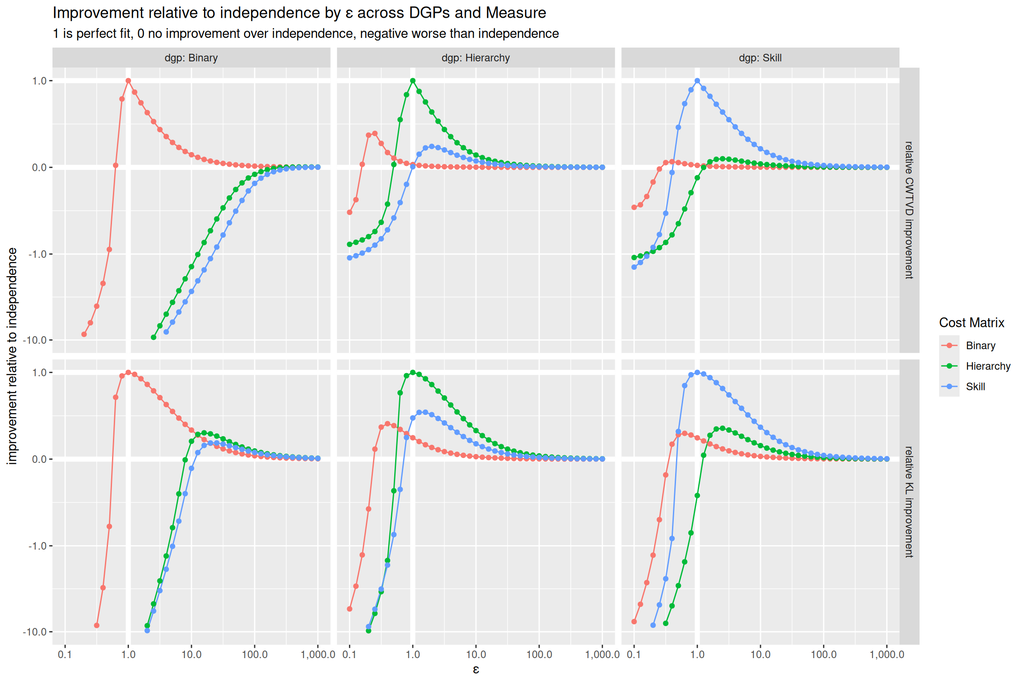

```r
sim_score_plots$sub_regime_measures
```

All three cost matrices assign zero cost to the diagonal, so all three transport plans over-concentrate mass on the diagonal at low $\varepsilon$, predicting less movement than actually occurs. Skill and hierarchy compound this by additionally over-concentrating on geometrically cheap off-diagonal pairs, leaving insufficient mass for transitions their cost structure scores as expensive. Binary’s over-concentration is confined to the diagonal alone, so it craters less severely — and its mechanical peak, where diagonal concentration just improves on independence before over-concentration takes over, occurs at a lower $\varepsilon$ than the true metric’s peak. This mechanical peak is not evidence that binary is competitive with the true metric; it is a property of the mathematics, not the data.

The winner of the horse race is the cost matrix whose peak relative improvement — maximised over the full $\varepsilon$ grid — is highest. This is the optimal transport analog to maximum likelihood model selection: the EROT plan $P^\star_{ij} = u_i e^{-C_{ij}/\varepsilon} v_j$ is the equilibrium of a multinomial logit discrete choice model, and comparing models by their maximised likelihood is equivalent to comparing their peak relative KL improvement. Peak CWTVD improvement is reported alongside KL as a complementary criterion: in a horse race about the geometry of mobility, closeness matters, and CWTVD penalises misallocation in proportion to how far the mass is from where it should be, where KL does not. A result is declared a tie when the peak improvements of the leading metrics are indistinguishable — the 50/50 skill/hierarchy panel below illustrates what a genuine tie looks like.

## The higher resolution of CWTVD

In the plot below, the peak score gap between the two leading cost metrics under relative CWTVD improvement (top row) widens as the data-generating mixture departs from balance — largest at 75/25 and 25/75, closing to a tie at the even 50/50 mixture, where a tie is the correct verdict. Relative KL improvement (bottom row) holds the two close to coincident across all three mixtures, resolving the imbalance only weakly. Note also the binary curve (red): under CWTVD its improvement collapses to the independence line after its peak, while under KL it retains a positive tail — KL rewards binary for reproducing the aggregate stay/move split regardless of where movers go, a credit CWTVD withholds.

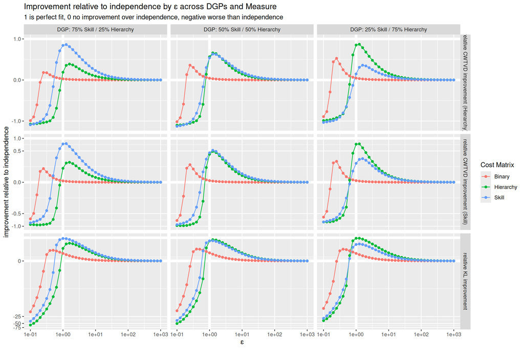

```r
sim_score_plots$global_measures
```